# Data transformation and manipulation

Author

Saar Alon-Barkat

Published

May 1, 2024

Importing Libraries

```r
library(tidyverse)
library(janitor)
```

In this session, we will practice data transformation and data manipulation techniques which are extremely important for working with data. In fact, in most data projects, most of your time will be spent on this.

We will divide the techniques to 4 different categories:

1. Organizing the dataset
2. Transforming variables
3. Aggregating the data
4. Combining/merging different datasets

We will also learn how to “reshape” the data (from long to wide and vice versa).

We will work mainly with the localities dataset, already available in the shared dropbox. This dataset is based on the local authorities dataset published by the CBS.

```r
#You can download and import, but here I also show you how you can download it directly from the web!

localities_2022 <- read_csv("https://www.dropbox.com/scl/fi/io3s84jk1mftpv9xnr2yf/localities_2022.csv?rlkey=xj42l8thfpmrm93l02wao8s69&st=72vb8hix&dl=1")
```

```r
localities_2022 %>% glimpse()
```

```
Rows: 256
Columns: 24
$ name                            <chr> "אום אל-פחם", "אופקים", "אור יהודה", "…
$ name_eng                        <chr> "Umm alFahm", "Ofaqim", "Or Yehuda", "…
$ symbol                          <dbl> 2710, 31, 2400, 1020, 2600, 1309, 3570…
$ type_eng                        <chr> "municipality", "municipality", "munic…
$ type                            <chr> "עירייה", "עירייה", "עירייה", "עירייה"…
$ population                      <dbl> 58665, 35506, 38854, 20874, 53151, 494…
$ rank                            <dbl> 2, 3, 5, 5, 6, 2, 6, 5, 5, 4, 7, 5, 5,…
$ distance_tlv                    <dbl> 60.6, 87.1, 0.0, 39.4, 323.0, 11.6, 33…
$ district_eng                    <chr> "Haifa", "South", "Tel Aviv", "Haifa",…
$ district                        <chr> "חיפה", "הדרום", "תל אביב", "חיפה", "ה…
$ class_size                      <dbl> 27, 24, 24, 24, 25, 25, 25, 26, 28, 27…
$ bagrut                          <dbl> 69.8, 52.1, 84.3, 88.1, 76.2, 24.6, 88…
$ teacher_student_ratio           <dbl> 10.7, 10.4, 10.8, 9.6, 10.0, 14.0, 9.8…
$ income                          <dbl> 7361, 8849, 9889, 9831, 10236, 7407, 1…
$ percent_arab                    <dbl> 99.9, 0.0, 0.0, 0.0, 4.9, 0.0, 0.0, 0.…
$ life_expectancy                 <dbl> 78.8, NA, NA, NA, 80.5, NA, NA, 82.5, …
$ diabetes                        <dbl> 109.3, 68.7, 64.9, 66.1, 54.9, 56.1, 5…
$ obesity_grade1                  <dbl> 20.7, 19.4, 19.8, 15.2, 21.0, 13.0, 16…
$ obesity_grade7                  <dbl> 46.5, 31.8, 34.6, 28.5, 37.0, 23.4, 25…
$ cancer_men                      <chr> "313", "343.1", "306", NA, "374.9", "2…
$ cancer_women                    <chr> "219.1", "353.7", "275.1", NA, "348", …
$ voting_rate_knesset_2021        <dbl> 33.1, 61.0, 66.8, 59.4, 41.3, 81.0, 61…
$ voting_rate_knesset_2022        <dbl> 33.1, 61.0, 66.8, 59.4, 41.3, 81.0, 61…
$ voting_rate_municipalities_2018 <dbl> 74.2, 68.9, 65.8, 65.5, 46.2, 84.1, 60…
```

Before starting - a general comment is needed about working with datasets as objects in R. In R, every table is an object (called “dataframe”), which can be saved in the working environment. When you make transformations to your data, you can do one of three things:

1. Printing the results without saving it. This is handy if you don’t think you will conduct additional analyses on the table, and you just want to view it. (Usually this is what we will do with `arrange` and `select`).
2. Saving the results as a new object, assigned with a new name. This is handy if you will want to continue using the previous table without the changes.(Usually this is what we will do with `filter`, and `left_join`).
3. Overriding the existing table. Saving the results as the existing table, using the same name. This is handy if you do not think you will use the previous table. (Usually this is what we will do with `mutate`).

# 1. Organizing the data

## Selecting columns with `select`

```r
localities_2022 %>%
  select(name,
         population,
         income) %>%
  head() # this prints only first raws
```

```
# A tibble: 6 × 3
  name       population income
  <chr>           <dbl>  <dbl>
1 אום אל-פחם      58665   7361
2 אופקים          35506   8849
3 אור יהודה       38854   9889
4 אור עקיבא       20874   9831
5 אילת            53151  10236
6 אלעד            49487   7407
```

Remember, you can also save it to a new dataset and give it a new name.

```r
localities_2022_short <- localities_2022 %>%
  select(name,
         population,
         income)
```

You can also “unselect” columns with “-”:

```r
localities_2022 %>%
  select(-cancer_men,
         -cancer_women) %>%
  head()
```

```
# A tibble: 6 × 22
  name       name_eng   symbol type_eng     type   population  rank distance_tlv
  <chr>      <chr>       <dbl> <chr>        <chr>       <dbl> <dbl>        <dbl>
1 אום אל-פחם Umm alFahm   2710 municipality עירייה      58665     2         60.6
2 אופקים     Ofaqim         31 municipality עירייה      35506     3         87.1
3 אור יהודה  Or Yehuda    2400 municipality עירייה      38854     5          0
4 אור עקיבא  Or Aqiva     1020 municipality עירייה      20874     5         39.4
5 אילת       Elat         2600 municipality עירייה      53151     6        323
6 אלעד       El'ad        1309 municipality עירייה      49487     2         11.6
# ℹ 14 more variables: district_eng <chr>, district <chr>, class_size <dbl>,
#   bagrut <dbl>, teacher_student_ratio <dbl>, income <dbl>,
#   percent_arab <dbl>, life_expectancy <dbl>, diabetes <dbl>,
#   obesity_grade1 <dbl>, obesity_grade7 <dbl>, voting_rate_knesset_2021 <dbl>,
#   voting_rate_knesset_2022 <dbl>, voting_rate_municipalities_2018 <dbl>
```

## Filtering raws with `filter`

Here are a few examples, using different logical operators:

```r
localities_2022 %>%
  filter(district_eng=="Haifa")
```

```
# A tibble: 30 × 24
   name          name_eng    symbol type_eng type  population  rank distance_tlv
   <chr>         <chr>        <dbl> <chr>    <chr>      <dbl> <dbl>        <dbl>
 1 אום אל-פחם    Umm alFahm    2710 municip… עירי…      58665     2         60.6
 2 אור עקיבא     Or Aqiva      1020 municip… עירי…      20874     5         39.4
 3 באקה אל-גרביה Baqa AlGha…   6000 municip… עירי…      31397     4         40.6
 4 חדרה          Hadera        6500 municip… עירי…     103041     6         32.9
 5 חיפה          Haifa         4000 municip… עירי…     290306     7         79.6
 6 חריש          Harish        1247 municip… עירי…      33380     5         48.7
 7 טירת כרמל     Tirat Karm…   2100 municip… עירי…      28753     5         69.7
 8 נשר           Nesher        2500 municip… עירי…      23761     7         81.2
 9 קריית אתא     Qiryat Atta   6800 municip… עירי…      61142     6         86.5
10 קריית ביאליק  Qiryat Bia…   9500 municip… עירי…      44620     6         86.5
# ℹ 20 more rows
# ℹ 16 more variables: district_eng <chr>, district <chr>, class_size <dbl>,
#   bagrut <dbl>, teacher_student_ratio <dbl>, income <dbl>,
#   percent_arab <dbl>, life_expectancy <dbl>, diabetes <dbl>,
#   obesity_grade1 <dbl>, obesity_grade7 <dbl>, cancer_men <chr>,
#   cancer_women <chr>, voting_rate_knesset_2021 <dbl>,
#   voting_rate_knesset_2022 <dbl>, voting_rate_municipalities_2018 <dbl>
```

```r
localities_2022 %>%
  filter(district_eng!="Haifa")
```

```
# A tibble: 226 × 24
   name      name_eng    symbol type_eng     type  population  rank distance_tlv
   <chr>     <chr>        <dbl> <chr>        <chr>      <dbl> <dbl>        <dbl>
 1 אופקים    Ofaqim          31 municipality עירי…      35506     3         87.1
 2 אור יהודה Or Yehuda     2400 municipality עירי…      38854     5          0
 3 אילת      Elat          2600 municipality עירי…      53151     6        323
 4 אלעד      El'ad         1309 municipality עירי…      49487     2         11.6
 5 אריאל     Ari'el        3570 municipality עירי…      20520     6         33.3
 6 אשדוד     Ashdod          70 municipality עירי…     226827     5         28.5
 7 אשקלון    Ashqelon      7100 municipality עירי…     153138     5         43.7
 8 באר יעקב  Beer Yaakov   2530 municipality עירי…      31325     7          9.7
 9 באר שבע   Be'er Sheva   9000 municipality עירי…     214162     5         91.5
10 בית שאן   Bet She'an    9200 municipality עירי…      19073     5         99.5
# ℹ 216 more rows
# ℹ 16 more variables: district_eng <chr>, district <chr>, class_size <dbl>,
#   bagrut <dbl>, teacher_student_ratio <dbl>, income <dbl>,
#   percent_arab <dbl>, life_expectancy <dbl>, diabetes <dbl>,
#   obesity_grade1 <dbl>, obesity_grade7 <dbl>, cancer_men <chr>,
#   cancer_women <chr>, voting_rate_knesset_2021 <dbl>,
#   voting_rate_knesset_2022 <dbl>, voting_rate_municipalities_2018 <dbl>
```

```r
localities_2022 %>%
  filter(distance_tlv>50)
```

```
# A tibble: 122 × 24
   name       name_eng     symbol type_eng   type  population  rank distance_tlv
   <chr>      <chr>         <dbl> <chr>      <chr>      <dbl> <dbl>        <dbl>
 1 אום אל-פחם Umm alFahm     2710 municipal… עירי…      58665     2         60.6
 2 אופקים     Ofaqim           31 municipal… עירי…      35506     3         87.1
 3 אילת       Elat           2600 municipal… עירי…      53151     6        323
 4 באר שבע    Be'er Sheva    9000 municipal… עירי…     214162     5         91.5
 5 בית שאן    Bet She'an     9200 municipal… עירי…      19073     5         99.5
 6 ביתר עילית Betar Illit    3780 municipal… עירי…      64016     1         59.1
 7 דימונה     Dimona         2200 municipal… עירי…      36776     5        129.
 8 חיפה       Haifa          4000 municipal… עירי…     290306     7         79.6
 9 טבריה      Tiberias       6700 municipal… עירי…      48472     4        114.
10 טירת כרמל  Tirat Karmel   2100 municipal… עירי…      28753     5         69.7
# ℹ 112 more rows
# ℹ 16 more variables: district_eng <chr>, district <chr>, class_size <dbl>,
#   bagrut <dbl>, teacher_student_ratio <dbl>, income <dbl>,
#   percent_arab <dbl>, life_expectancy <dbl>, diabetes <dbl>,
#   obesity_grade1 <dbl>, obesity_grade7 <dbl>, cancer_men <chr>,
#   cancer_women <chr>, voting_rate_knesset_2021 <dbl>,
#   voting_rate_knesset_2022 <dbl>, voting_rate_municipalities_2018 <dbl>
```

```r
localities_2022 %>%
  filter(distance_tlv<50)
```

```
# A tibble: 79 × 24
   name          name_eng    symbol type_eng type  population  rank distance_tlv
   <chr>         <chr>        <dbl> <chr>    <chr>      <dbl> <dbl>        <dbl>
 1 אור יהודה     Or Yehuda     2400 municip… עירי…      38854     5          0
 2 אור עקיבא     Or Aqiva      1020 municip… עירי…      20874     5         39.4
 3 אלעד          El'ad         1309 municip… עירי…      49487     2         11.6
 4 אריאל         Ari'el        3570 municip… עירי…      20520     6         33.3
 5 אשדוד         Ashdod          70 municip… עירי…     226827     5         28.5
 6 אשקלון        Ashqelon      7100 municip… עירי…     153138     5         43.7
 7 באקה אל-גרביה Baqa AlGha…   6000 municip… עירי…      31397     4         40.6
 8 באר יעקב      Beer Yaakov   2530 municip… עירי…      31325     7          9.7
 9 בית שמש       Bet Shemesh   2610 municip… עירי…     154694     2         43.2
10 בני ברק       Bene Beraq    6100 municip… עירי…     218357     2          0
# ℹ 69 more rows
# ℹ 16 more variables: district_eng <chr>, district <chr>, class_size <dbl>,
#   bagrut <dbl>, teacher_student_ratio <dbl>, income <dbl>,
#   percent_arab <dbl>, life_expectancy <dbl>, diabetes <dbl>,
#   obesity_grade1 <dbl>, obesity_grade7 <dbl>, cancer_men <chr>,
#   cancer_women <chr>, voting_rate_knesset_2021 <dbl>,
#   voting_rate_knesset_2022 <dbl>, voting_rate_municipalities_2018 <dbl>
```

```r
localities_2022 %>%
  filter(district_eng=="Haifa" & distance_tlv<50) # '&' = and
```

```
# A tibble: 9 × 24
  name             name_eng  symbol type_eng type  population  rank distance_tlv
  <chr>            <chr>      <dbl> <chr>    <chr>      <dbl> <dbl>        <dbl>
1 אור עקיבא        Or Aqiva    1020 municip… עירי…      20874     5         39.4
2 באקה אל-גרביה    Baqa AlG…   6000 municip… עירי…      31397     4         40.6
3 חדרה             Hadera      6500 municip… עירי…     103041     6         32.9
4 חריש             Harish      1247 municip… עירי…      33380     5         48.7
5 בנימינה-גבעת עדה Binyamin…   9800 local m… מועצ…      16281     8         45.2
6 ג'סר א-זרקא      Jisr AzZ…    541 local m… מועצ…      15502     2         44.5
7 ג'ת              Jatt         628 local m… מועצ…      12645     5         38.3
8 זכרון יעקב       Zikhron …   9300 local m… מועצ…      24145     8         48.8
9 פרדס חנה-כרכור   Pardes H…   7800 local m… מועצ…      44840     7         41.2
# ℹ 16 more variables: district_eng <chr>, district <chr>, class_size <dbl>,
#   bagrut <dbl>, teacher_student_ratio <dbl>, income <dbl>,
#   percent_arab <dbl>, life_expectancy <dbl>, diabetes <dbl>,
#   obesity_grade1 <dbl>, obesity_grade7 <dbl>, cancer_men <chr>,
#   cancer_women <chr>, voting_rate_knesset_2021 <dbl>,
#   voting_rate_knesset_2022 <dbl>, voting_rate_municipalities_2018 <dbl>
```

```r
localities_2022 %>%
  filter(district_eng=="Haifa" | distance_tlv<50) # `|`= or
```

```
# A tibble: 100 × 24
   name          name_eng    symbol type_eng type  population  rank distance_tlv
   <chr>         <chr>        <dbl> <chr>    <chr>      <dbl> <dbl>        <dbl>
 1 אום אל-פחם    Umm alFahm    2710 municip… עירי…      58665     2         60.6
 2 אור יהודה     Or Yehuda     2400 municip… עירי…      38854     5          0
 3 אור עקיבא     Or Aqiva      1020 municip… עירי…      20874     5         39.4
 4 אלעד          El'ad         1309 municip… עירי…      49487     2         11.6
 5 אריאל         Ari'el        3570 municip… עירי…      20520     6         33.3
 6 אשדוד         Ashdod          70 municip… עירי…     226827     5         28.5
 7 אשקלון        Ashqelon      7100 municip… עירי…     153138     5         43.7
 8 באקה אל-גרביה Baqa AlGha…   6000 municip… עירי…      31397     4         40.6
 9 באר יעקב      Beer Yaakov   2530 municip… עירי…      31325     7          9.7
10 בית שמש       Bet Shemesh   2610 municip… עירי…     154694     2         43.2
# ℹ 90 more rows
# ℹ 16 more variables: district_eng <chr>, district <chr>, class_size <dbl>,
#   bagrut <dbl>, teacher_student_ratio <dbl>, income <dbl>,
#   percent_arab <dbl>, life_expectancy <dbl>, diabetes <dbl>,
#   obesity_grade1 <dbl>, obesity_grade7 <dbl>, cancer_men <chr>,
#   cancer_women <chr>, voting_rate_knesset_2021 <dbl>,
#   voting_rate_knesset_2022 <dbl>, voting_rate_municipalities_2018 <dbl>
```

## Arranging raws with `arrange`

```r
localities_2022 %>%
  arrange(distance_tlv)
```

```
# A tibble: 256 × 24
   name         name_eng     symbol type_eng type  population  rank distance_tlv
   <chr>        <chr>         <dbl> <chr>    <chr>      <dbl> <dbl>        <dbl>
 1 אור יהודה    Or Yehuda      2400 municip… עירי…      38854     5            0
 2 בני ברק      Bene Beraq     6100 municip… עירי…     218357     2            0
 3 בת ים        Bat Yam        6200 municip… עירי…     128465     5            0
 4 גבעתיים      Giv'atayim     6300 municip… עירי…      61924     9            0
 5 הרצלייה      Herzliyya      6400 municip… עירי…     106741     8            0
 6 חולון        Holon          6600 municip… עירי…     197957     7            0
 7 קריית אונו   Qiryat Ono     2620 municip… עירי…      43241     9            0
 8 רמת גן       Ramat Gan      8600 municip… עירי…     172486     8            0
 9 רמת השרון    Ramat HaSha…   2650 municip… עירי…      48181     9            0
10 תל אביב -יפו Tel Aviv  Y…   5000 municip… עירי…     474530     8            0
# ℹ 246 more rows
# ℹ 16 more variables: district_eng <chr>, district <chr>, class_size <dbl>,
#   bagrut <dbl>, teacher_student_ratio <dbl>, income <dbl>,
#   percent_arab <dbl>, life_expectancy <dbl>, diabetes <dbl>,
#   obesity_grade1 <dbl>, obesity_grade7 <dbl>, cancer_men <chr>,
#   cancer_women <chr>, voting_rate_knesset_2021 <dbl>,
#   voting_rate_knesset_2022 <dbl>, voting_rate_municipalities_2018 <dbl>
```

```r
localities_2022 %>%
  arrange(distance_tlv %>% desc())
```

```
# A tibble: 256 × 24
   name        name_eng      symbol type_eng type  population  rank distance_tlv
   <chr>       <chr>          <dbl> <chr>    <chr>      <dbl> <dbl>        <dbl>
 1 אילת        Elat            2600 municip… עירי…      53151     6         323
 2 מג'דל שמס   Majdal Shams    4201 local m… מועצ…      11458     3         185
 3 עין קנייא   Ein Qiniyye     4502 local m… מועצ…       2190     3         184.
 4 מסעדה       Mas'ade         4203 local m… מועצ…       3869     2         181.
 5 בוקעאתא     Buq'ata         4001 local m… מועצ…       6805     3         180.
 6 ע'ג'ר       Ghajar          4501 local m… מועצ…       2806     3         179.
 7 מצפה רמון   Mizpe Ramon       99 local m… מועצ…       5263     3         172
 8 מטולה       Metula            43 local m… מועצ…       1740     7         172.
 9 קריית שמונה Qiryat Shemo…   2800 municip… עירי…      22492     5         163.
10 קצרין       Qazrin          4100 local m… מועצ…       7876     5         156.
# ℹ 246 more rows
# ℹ 16 more variables: district_eng <chr>, district <chr>, class_size <dbl>,
#   bagrut <dbl>, teacher_student_ratio <dbl>, income <dbl>,
#   percent_arab <dbl>, life_expectancy <dbl>, diabetes <dbl>,
#   obesity_grade1 <dbl>, obesity_grade7 <dbl>, cancer_men <chr>,
#   cancer_women <chr>, voting_rate_knesset_2021 <dbl>,
#   voting_rate_knesset_2022 <dbl>, voting_rate_municipalities_2018 <dbl>
```

```r
localities_2022 %>%
  arrange(rank)
```

```
# A tibble: 256 × 24
   name          name_eng    symbol type_eng type  population  rank distance_tlv
   <chr>         <chr>        <dbl> <chr>    <chr>      <dbl> <dbl>        <dbl>
 1 ביתר עילית    Betar Illit   3780 municip… עירי…      64016     1         59.1
 2 מודיעין עילית Modi'inMak…   3797 municip… עירי…      83356     1         27.5
 3 רהט           Rahat         1161 municip… עירי…      79064     1         76.7
 4 חורה          Hura          1303 local m… מועצ…      24822     1         93.9
 5 כסיפה         Kuseife       1059 local m… מועצ…      23990     1        110.
 6 לקיה          Laqye         1060 local m… מועצ…      16011     1         87.5
 7 ערערה-בנגב    Ar'araBaNe…   1192 local m… מועצ…      20381     1        119.
 8 שגב-שלום      SegevShalom   1286 local m… מועצ…      12540     1        100.
 9 תל שבע        Tel Sheva     1054 local m… מועצ…      22849     1         95.6
10 אל קסום       <NA>            69 regiona… מועצ…      18101     1         NA
# ℹ 246 more rows
# ℹ 16 more variables: district_eng <chr>, district <chr>, class_size <dbl>,
#   bagrut <dbl>, teacher_student_ratio <dbl>, income <dbl>,
#   percent_arab <dbl>, life_expectancy <dbl>, diabetes <dbl>,
#   obesity_grade1 <dbl>, obesity_grade7 <dbl>, cancer_men <chr>,
#   cancer_women <chr>, voting_rate_knesset_2021 <dbl>,
#   voting_rate_knesset_2022 <dbl>, voting_rate_municipalities_2018 <dbl>
```

```r
localities_2022 %>%
  arrange(rank,
          distance_tlv)
```

```
# A tibble: 256 × 24
   name          name_eng    symbol type_eng type  population  rank distance_tlv
   <chr>         <chr>        <dbl> <chr>    <chr>      <dbl> <dbl>        <dbl>
 1 מודיעין עילית Modi'inMak…   3797 municip… עירי…      83356     1         27.5
 2 ביתר עילית    Betar Illit   3780 municip… עירי…      64016     1         59.1
 3 רהט           Rahat         1161 municip… עירי…      79064     1         76.7
 4 לקיה          Laqye         1060 local m… מועצ…      16011     1         87.5
 5 חורה          Hura          1303 local m… מועצ…      24822     1         93.9
 6 תל שבע        Tel Sheva     1054 local m… מועצ…      22849     1         95.6
 7 שגב-שלום      SegevShalom   1286 local m… מועצ…      12540     1        100.
 8 כסיפה         Kuseife       1059 local m… מועצ…      23990     1        110.
 9 ערערה-בנגב    Ar'araBaNe…   1192 local m… מועצ…      20381     1        119.
10 אל קסום       <NA>            69 regiona… מועצ…      18101     1         NA
# ℹ 246 more rows
# ℹ 16 more variables: district_eng <chr>, district <chr>, class_size <dbl>,
#   bagrut <dbl>, teacher_student_ratio <dbl>, income <dbl>,
#   percent_arab <dbl>, life_expectancy <dbl>, diabetes <dbl>,
#   obesity_grade1 <dbl>, obesity_grade7 <dbl>, cancer_men <chr>,
#   cancer_women <chr>, voting_rate_knesset_2021 <dbl>,
#   voting_rate_knesset_2022 <dbl>, voting_rate_municipalities_2018 <dbl>
```

At the end of this document we return to two extra functions for organizing the data: reshaping/pivoting (`pivot_wider` and `pivot_longer`).

# 2. Transforming variables (with `mutate`)

With `mutate` we can create new variables or override existing variables.

The code will be usually: `data %>% mutate(new_var = ...)`

For example - let’s create a `year` variable that will receive 2022 for all raws. Let’s save it into the dataset (override).

```r
localities_2022 <- localities_2022 %>%
mutate(year = 2022)
```

## Recoding categorical variables with `recode`

```r
localities_2022 <- localities_2022 %>%
  mutate(new_district = district_eng %>%
           recode(Haifa="North",
                  `Tel Aviv` = "Center"))

localities_2022 %>% count(new_district)
```

```
# A tibble: 5 × 2
  new_district     n
  <chr>        <int>
1 Center          64
2 Jerusalem        6
3 North          123
4 South           39
5 Yosh            24
```

```r
localities_2022 <- localities_2022 %>%
  mutate(new_rank = rank %>%
           recode(`1`="Low",
                  `2`="Low",
                  `3`="Low",
                  `4`="Medium",
                  `5`="Medium",
                  `6`="Medium",
                  `7`="Medium",
                  `8`="High",
                  `9`="High",
                  `10`="High"))

localities_2022 %>% count(rank,new_rank)
```

```
# A tibble: 11 × 3
    rank new_rank     n
   <dbl> <chr>    <int>
 1     1 Low         11
 2     2 Low         26
 3     3 Low         37
 4     4 Medium      20
 5     5 Medium      43
 6     6 Medium      25
 7     7 Medium      46
 8     8 High        26
 9     9 High        16
10    10 High         5
11    NA <NA>         1
```

## Transforming variables based on logical rules with `case_when`

`case_when` allows us to transform not only categorical variables but also numeric variables.

```r
localities_2022 <- localities_2022 %>%
  mutate(arab_locality_1 = case_when(
    percent_arab==100 ~ "Arab",
    percent_arab==0 ~ "Jewish",
    TRUE ~ "Mixed"
  )
  )

localities_2022 %>% count(arab_locality_1)
```

```
# A tibble: 3 × 2
  arab_locality_1     n
  <chr>           <int>
1 Arab               20
2 Jewish            148
3 Mixed              88
```

```r
localities_2022 <- localities_2022 %>%
  mutate(arab_locality_2 = case_when(
    percent_arab>=90 ~ "Arab",
    percent_arab<=10 ~ "Jewish",
    TRUE ~ "Mixed"
  )
  )

localities_2022 %>% count(arab_locality_2)
```

```
# A tibble: 3 × 2
  arab_locality_2     n
  <chr>           <int>
1 Arab               85
2 Jewish            158
3 Mixed              13
```

## Transforming variables based on formula

This can be very useful for many purposes.

```r
localities_2022 <- localities_2022 %>%
  mutate(turnout_increase_2022_2021 = (voting_rate_knesset_2022 - voting_rate_knesset_2021))

localities_2022 %>%
  select(name,
         turnout_increase_2022_2021,
         voting_rate_knesset_2022,
         voting_rate_knesset_2021) %>%
  arrange(turnout_increase_2022_2021 %>% desc())
```

```
# A tibble: 256 × 4
   name     turnout_increase_202…¹ voting_rate_knesset_…² voting_rate_knesset_…³
   <chr>                     <dbl>                  <dbl>                  <dbl>
 1 מזכרת ב…                   57.2                   74.8                   17.6
 2 עמנואל                     57                     67.3                   10.3
 3 מעיליא                     45.6                   65                     19.4
 4 רכסים                      36.4                   81.7                   45.3
 5 אלונה                      32.9                   76.1                   43.2
 6 בני שמע…                   31.1                   74.6                   43.5
 7 שוהם                       26.1                   75.4                   49.3
 8 נחל שורק                   24.7                   81.5                   56.8
 9 סביון                      21.9                   68.7                   46.8
10 עומר                       20.5                   68.9                   48.4
# ℹ 246 more rows
# ℹ abbreviated names: ¹turnout_increase_2022_2021, ²voting_rate_knesset_2022,
#   ³voting_rate_knesset_2021
```

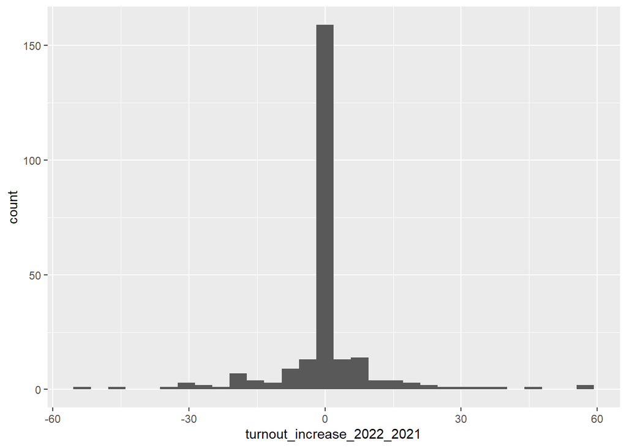

```r
localities_2022 %>%
  ggplot(aes(turnout_increase_2022_2021))+
  geom_histogram()
```

# 3. Aggregating the data (with `group_by` and `summarize`)

Often we want to aggregate/group/cluster to a higher level.

For this, we can use `group_by` and `summarise`. The code will be usually: `data %>% group_by(group_var) %>% summarize(...)`

For example, let’s aggregate the data at the district level.

```r
localities_2022 %>%
  group_by(district_eng) %>%
  summarise(sum(population),
            mean(voting_rate_knesset_2022),
            mean(income),
            median(rank),
            max(rank),
            mean(teacher_student_ratio,na.rm = T))
```

```
# A tibble: 7 × 7
  district_eng `sum(population)` `mean(voting_rate_knesset_2022)` `mean(income)`
  <chr>                    <dbl>                            <dbl>          <dbl>
1 Center                 2348269                             68.8         13626.
2 Haifa                  1124309                             54.1         10817.
3 Jerusalem              1239270                             62.4         10459
4 North                  1542095                             53.2          9278.
5 South                  1352594                             61.3         10679.
6 Tel Aviv               1506280                             65.4         15072.
7 Yosh                    477646                             NA              NA
# ℹ 3 more variables: `median(rank)` <dbl>, `max(rank)` <dbl>,
#   `mean(teacher_student_ratio, na.rm = T)` <dbl>
```

# 4. Combining/merging with a different dataset

## Combining with another dataset (with `bind_raws`)

Say our data was split to three tables: cities, local municipalities and regional councils. All tables have the same columns/variables.

```r
municipality <- localities_2022 %>%
  filter(type_eng=="municipality")

local_municipality <- localities_2022 %>%
  filter(type_eng=="local municipality")

regional_council <- localities_2022 %>%
  filter(type_eng=="regional council")
```

Now, we want to combine them into one table. We use `bind_raws` to put the tables one below each other.

```r
municipality %>%
  bind_rows(local_municipality) %>%
  bind_rows(regional_council)
```

```
# A tibble: 256 × 30
   name          name_eng    symbol type_eng type  population  rank distance_tlv
   <chr>         <chr>        <dbl> <chr>    <chr>      <dbl> <dbl>        <dbl>
 1 אום אל-פחם    Umm alFahm    2710 municip… עירי…      58665     2         60.6
 2 אופקים        Ofaqim          31 municip… עירי…      35506     3         87.1
 3 אור יהודה     Or Yehuda     2400 municip… עירי…      38854     5          0
 4 אור עקיבא     Or Aqiva      1020 municip… עירי…      20874     5         39.4
 5 אילת          Elat          2600 municip… עירי…      53151     6        323
 6 אלעד          El'ad         1309 municip… עירי…      49487     2         11.6
 7 אריאל         Ari'el        3570 municip… עירי…      20520     6         33.3
 8 אשדוד         Ashdod          70 municip… עירי…     226827     5         28.5
 9 אשקלון        Ashqelon      7100 municip… עירי…     153138     5         43.7
10 באקה אל-גרביה Baqa AlGha…   6000 municip… עירי…      31397     4         40.6
# ℹ 246 more rows
# ℹ 22 more variables: district_eng <chr>, district <chr>, class_size <dbl>,
#   bagrut <dbl>, teacher_student_ratio <dbl>, income <dbl>,
#   percent_arab <dbl>, life_expectancy <dbl>, diabetes <dbl>,
#   obesity_grade1 <dbl>, obesity_grade7 <dbl>, cancer_men <chr>,
#   cancer_women <chr>, voting_rate_knesset_2021 <dbl>,
#   voting_rate_knesset_2022 <dbl>, voting_rate_municipalities_2018 <dbl>, …
```

## Mergning with another dataset (with `join`)

Say found another information on our cases in another dataset, and we want to merge the two together. This can be tricky if the raws are not arranged exactly in the same order.

For example, let’s merge the localities data with another dataset by the CBS on specific settlements (not localities).

```r
yeshuvim_2020 <- read_csv("https://www.dropbox.com/s/2om27wotvw9i1x3/yeshuvim_cbs_2020.csv?dl=1")
```

```r
elections_2022 <- read_csv("https://www.dropbox.com/scl/fi/xwl1csshdld6s2hfy6bst/election_results_2022.csv?rlkey=d0dri3sbzc2tehf8o7z3yiyc1&st=4n1m1but&dl=1")

elections_2022 <- elections_2022 %>% janitor::clean_names()

elections_2022 %>% glimpse()
```

```
Rows: 1,216
Columns: 47
$ sml_w_dh <dbl> 18, 2, 6, 18, 18, 18, 18, 18, 18, 8, 20, 9, 3, 17, 10, 5, 2, …
$ sm_yswb  <chr> "אבו גווייעד שבט", "אבו גוש", "אבו סנאן", "אבו עבדון שבט", "א…
$ sml_yswb <dbl> 967, 472, 473, 958, 968, 1342, 966, 961, 1375, 652, 1275, 679…
$ bzb      <dbl> 2279, 5094, 10013, 154, 3386, 703, 4484, 5336, 1141, 1935, 32…
$ mzby_ym  <dbl> 549, 2809, 5458, 41, 1215, 351, 1496, 2105, 653, 875, 244, 40…
$ pswlym   <dbl> 9, 40, 76, 0, 6, 5, 23, 12, 6, 8, 0, 3, 1, 3, 4, 1, 1, 2, 19,…
$ ksrym    <dbl> 540, 2769, 5382, 41, 1209, 346, 1473, 2093, 647, 867, 244, 40…
$ mt       <dbl> 1, 14, 34, 0, 5, 2, 10, 0, 0, 1, 32, 36, 0, 38, 68, 2, 37, 29…
$ z        <dbl> 0, 1, 0, 0, 0, 0, 0, 0, 0, 0, 2, 0, 0, 1, 2, 0, 4, 1, 14, 0, …
$ b        <dbl> 0, 1, 3, 0, 1, 0, 0, 0, 0, 0, 5, 2, 2, 3, 1, 7, 2, 0, 59, 0, …
$ g        <dbl> 0, 3, 0, 0, 0, 1, 5, 0, 0, 0, 0, 2, 5, 1, 0, 6, 1, 0, 26, 0, …
$ d        <dbl> 4, 1263, 677, 1, 10, 6, 24, 35, 6, 74, 0, 1, 0, 0, 1, 0, 1, 0…
$ wm       <dbl> 38, 312, 2030, 1, 65, 9, 92, 392, 136, 195, 5, 3, 0, 0, 3, 0,…
```

[output cut: 34 more lines]

```r
new_dataset <- localities_2022 %>%
  filter(type_eng!="regional council") %>%
  left_join(elections_2022,
            by = c("symbol" = "sml_yswb"))
```

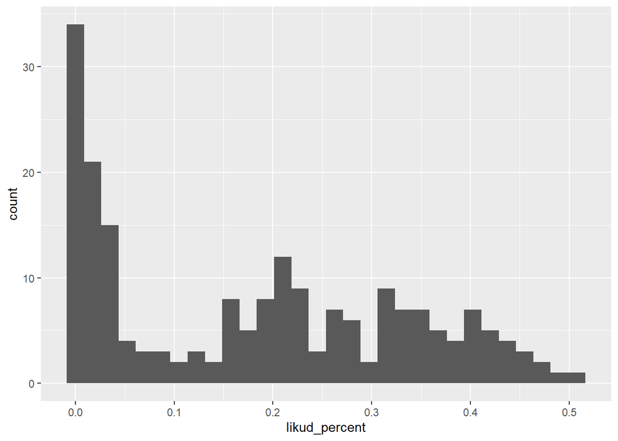

```r
new_dataset <- new_dataset %>%
  mutate(likud_percent = mhl/ksrym)

new_dataset %>%
  ggplot(aes(x=likud_percent))+
  geom_histogram()
```

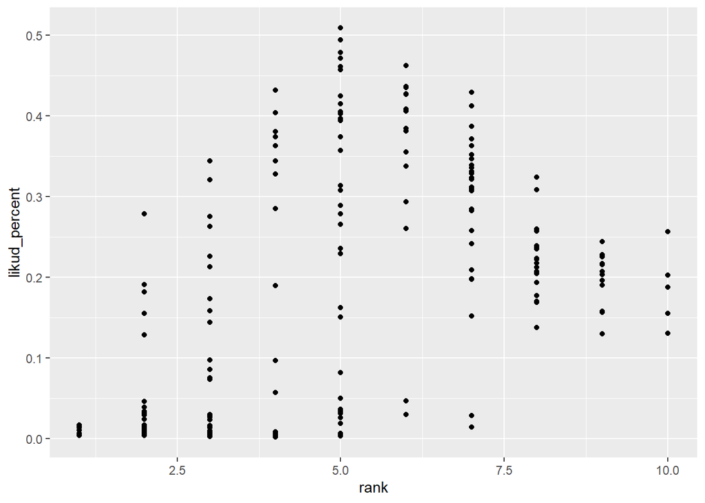

```r
new_dataset %>%
  ggplot(aes(x=rank,y=likud_percent))+
  geom_point()
```

# Reshaping data (long and wide forms)

```r
t1 <- localities_2022 %>%
  drop_na(name_eng) %>%
  select(name_eng,
         voting_rate_knesset_2022,
         voting_rate_municipalities_2018)
```

From wide to long (“pivot”):

```r
t1_longer <- t1 %>%
pivot_longer(cols=voting_rate_knesset_2022:voting_rate_municipalities_2018,
             names_to = "election",
             values_to = "turnout")
```

```r
t1_longer %>%
  group_by(election) %>%
  summarise(mean_turnout = mean(turnout,na.rm = T))
```

```
# A tibble: 2 × 2
  election                        mean_turnout
  <chr>                                  <dbl>
1 voting_rate_knesset_2022                57.6
2 voting_rate_municipalities_2018         73.2
```

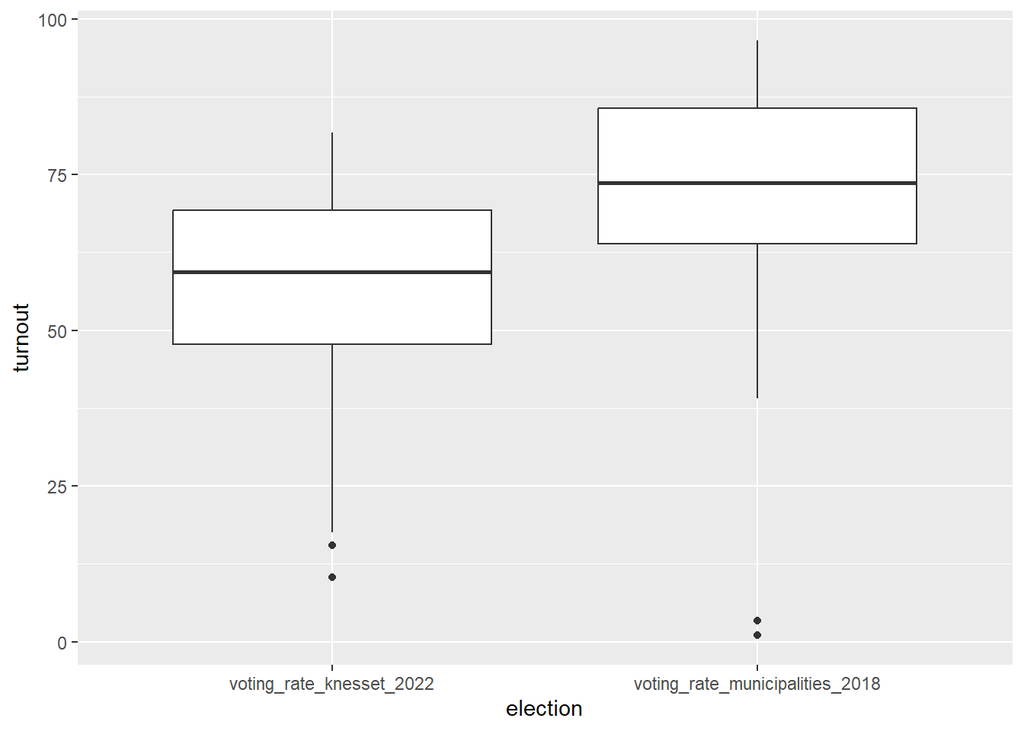

```r
t1_longer %>%
  ggplot(aes(x=election,y=turnout))+
  geom_boxplot()
```

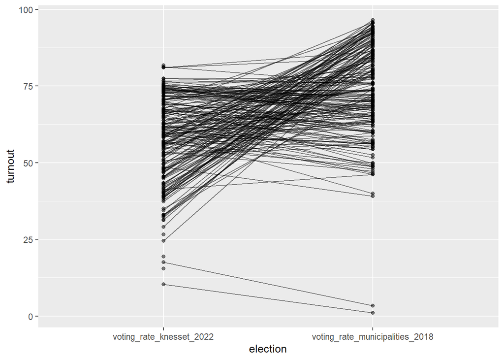

```r
t1_longer %>%
  ggplot(aes(x=election,y=turnout))+
  geom_point(alpha=0.5)+
  geom_line(aes(group=name_eng),alpha=0.5)
```

What can explain this… Where is the voting turnout for local elections higher than national elections. Any guess??

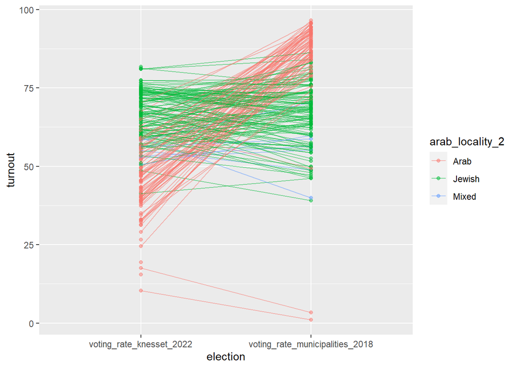

```r
t2 <- localities_2022 %>%
  drop_na(name_eng) %>%
  select(name_eng,
         voting_rate_knesset_2022,
         voting_rate_municipalities_2018,
         arab_locality_2)


t2_longer <- t2 %>%
pivot_longer(cols=voting_rate_knesset_2022:voting_rate_municipalities_2018,
             names_to = "election",
             values_to = "turnout")


t2_longer %>%
  ggplot(aes(x=election,y=turnout,color=arab_locality_2))+
  geom_point(alpha=0.5)+
  geom_line(aes(group=name_eng),alpha=0.5)
```

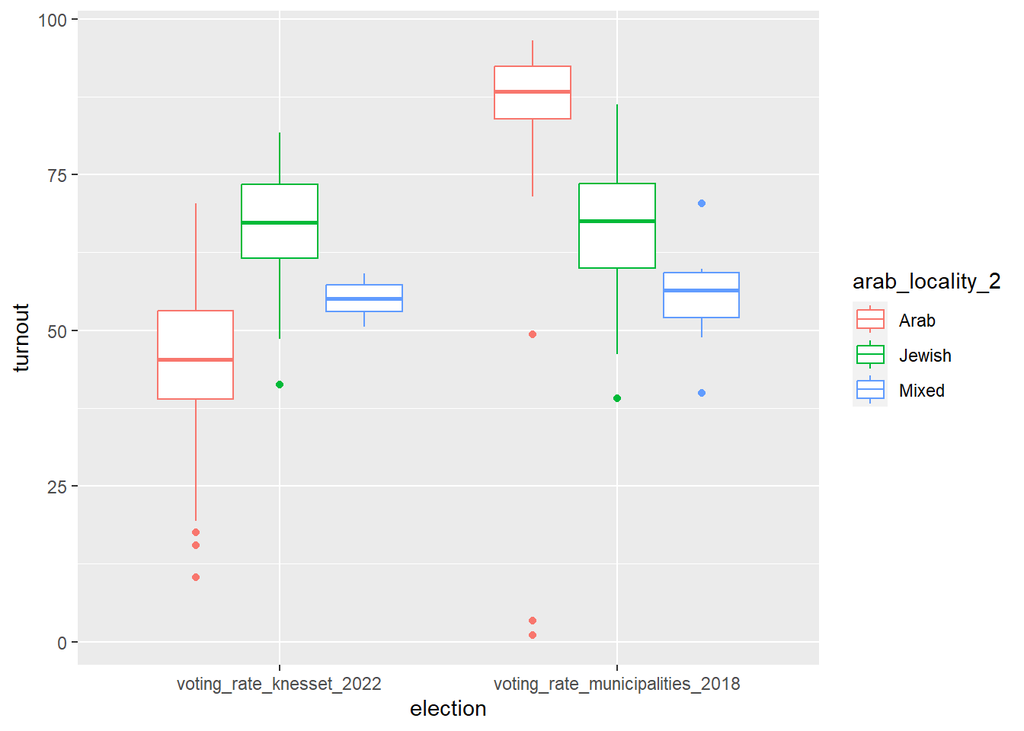

```r
t2_longer %>%
  ggplot(aes(x=election,y=turnout,color=arab_locality_2))+
  geom_boxplot()
```

From long to wide (“unpivot”):

```r
t1_wider <- t1_longer %>%
pivot_wider(names_from = election,
            values_from = turnout)
```